# Module 46

#### Hemi-module gene counts:

878 probesets in hemi-module A.  
353 probesets in hemi-module B.  
Note: While the mapping of probesets to genes is usually one-to-one, some genes are targeted by multiple probesets, some probesets target multiple genes, and some probesets do not target any genes (i.e., the region of the genome they match is no longer considered genic).

#### Contrast SVE:

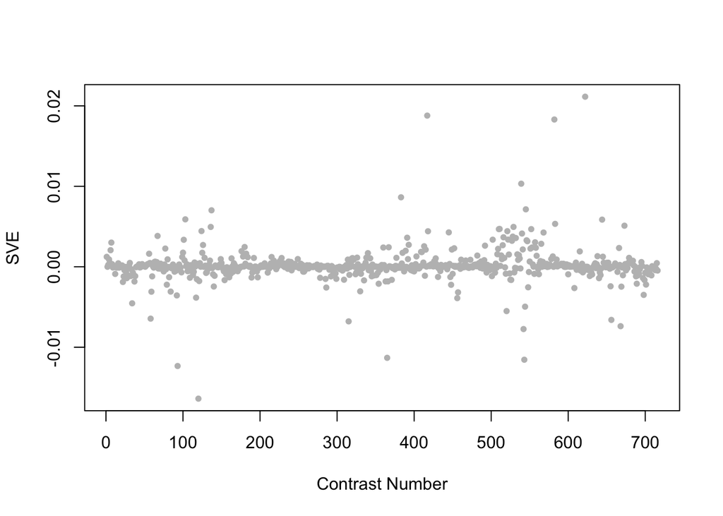

Positive SVE Contrasts:

|  | Contrast.Num | SVE | GEO.GSE | Cond.1 | Cond.2 | Mutation |
| --- | --- | --- | --- | --- | --- | --- |
| GSE21162.s1t1.vs.s0t1 | 622 | 0.02 | GSE21162 | PVD and OLL neurons, biological rep1 | L3/L4 stage whole animal reference, rep1 |  |
| GSE28856.s0t2.vs.s0t1 | 417 | 0.02 | GSE28856 | Wild-type 1 h after shifting temperature rep1 | Wild-type 0 h after shifting temperature rep1 |  |
| GSE2180.s2t2.vs.s2t1 | 582 | 0.02 | GSE2180 | ms23-1 | ms0-1 |  |
| GSE2180.s2t2.vs.s1t2 | 539 | 0.01 | GSE2180 | ms23-1 | 23-1 | mex-3(zu155);skn-1(RNAi) |
| GSE34113.s1t1.vs.s0t1 | 383 | 0.01 | GSE34113 | tdp-1(ok803) | wild-type 1 | tdp-1 |

Negative SVE Contrasts:

|  | Contrast.Num | SVE | GEO.GSE | Cond.1 | Cond.2 | Mutation |
| --- | --- | --- | --- | --- | --- | --- |
| GSE54024.s3t1.vs.s4t1 | 120 | -0.02 | GSE54024 | nuo-6(qm200) young adults, biological rep 1 | isp-1(qm150) young adults, biological rep 1 |  |
| GSE5801.s3t1.vs.s1t1 | 93 | -0.01 | GSE5801 | daf2pmk1_RepA | daf2_RepA | pmk-1 |
| GSE2180.s4t2.vs.s2t2 | 543 | -0.01 | GSE2180 | pp23-1 | ms23-1 |  |
| GSE36358.s3t1.vs.s0t1 | 365 | -0.01 | GSE36358 | Hyper Gravity | Ground Control (Tsukuba space center) |  |
| GSE2180.s3t2.vs.s2t2 | 542 | -0.01 | GSE2180 | p23-2 | ms23-1 |  |

$~$

#### Contrast SVE, Up-Regulated Genes Only:

Calculating SVE for up-regulated and down-regulated genes separately may be more informative in many cases than projecting the up- and down- gene sets together. This is due to the fact that the weight distribution of many modules is highly skewed, indicating that only one of the hemi-modules may be biologically meaningful (i.e., a set of genes are strongly correlated by only a few genes (or none) are strongly anti-correlated to that set.)

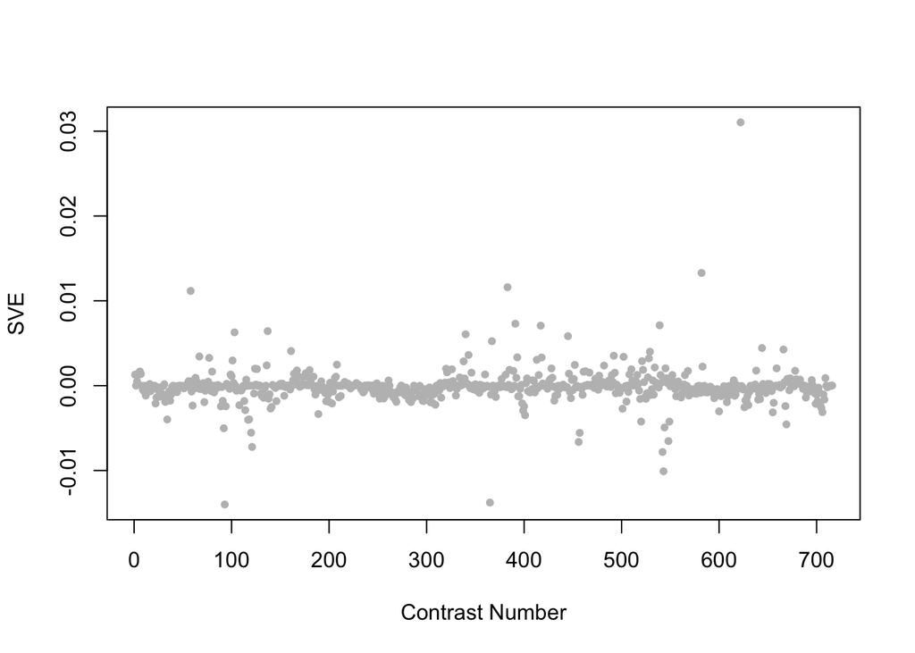

Positive SVE Contrasts:

|  | Contrast.Num | SVE | GEO.GSE | Cond.1 | Cond.2 | Mutation |
| --- | --- | --- | --- | --- | --- | --- |
| GSE21162.s1t1.vs.s0t1 | 622 | 0.03 | GSE21162 | PVD and OLL neurons, biological rep1 | L3/L4 stage whole animal reference, rep1 |  |
| GSE2180.s2t2.vs.s2t1 | 582 | 0.01 | GSE2180 | ms23-1 | ms0-1 |  |
| GSE34113.s1t1.vs.s0t1 | 383 | 0.01 | GSE34113 | tdp-1(ok803) | wild-type 1 | tdp-1 |
| GSE9485.s2t1.vs.s1t1 | 58 | 0.01 | GSE9485 | Larval Reference, biological rep 1 | Larval Pan-neural, biological rep 1 |  |
| GSE32467.s1t1.vs.s0t1 | 391 | 0.01 | GSE32467 | unc-37(e262) A-class, biological rep1 | wildtype A-class, biological rep1 | unc-37 |

Negative SVE Contrasts:

|  | Contrast.Num | SVE | GEO.GSE | Cond.1 | Cond.2 | Mutation |
| --- | --- | --- | --- | --- | --- | --- |
| GSE5801.s3t1.vs.s1t1 | 93 | -0.01 | GSE5801 | daf2pmk1_RepA | daf2_RepA | pmk-1 |
| GSE36358.s3t1.vs.s0t1 | 365 | -0.01 | GSE36358 | Hyper Gravity | Ground Control (Tsukuba space center) |  |
| GSE2180.s4t2.vs.s2t2 | 543 | -0.01 | GSE2180 | pp23-1 | ms23-1 |  |
| GSE2180.s3t2.vs.s2t2 | 542 | -0.01 | GSE2180 | p23-2 | ms23-1 |  |
| GSE54024.s2t1.vs.s4t1 | 121 | -0.01 | GSE54024 | Wild type young adults treated with 0.1mM paraquat, biological rep 1 | isp-1(qm150) young adults, biological rep 1 |  |

$~$

#### Contrast SVE, Down-Regulated Genes Only:

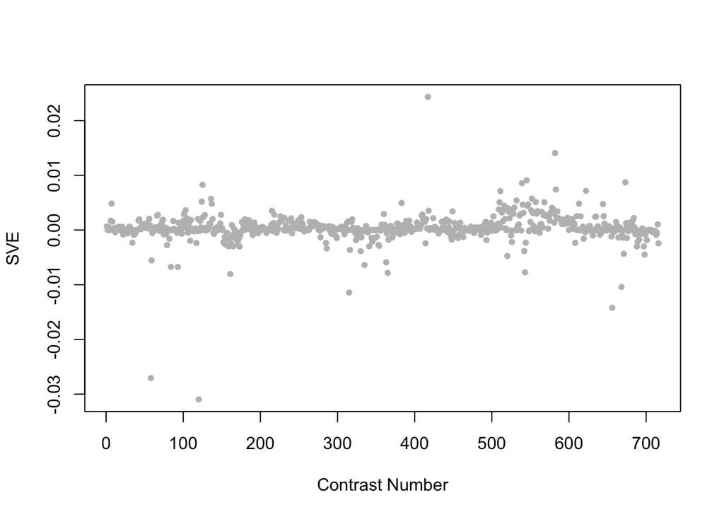

Positive SVE Contrasts:

|  | Contrast.Num | SVE | GEO.GSE | Cond.1 | Cond.2 | Mutation |
| --- | --- | --- | --- | --- | --- | --- |
| GSE28856.s0t2.vs.s0t1 | 417 | 0.02 | GSE28856 | Wild-type 1 h after shifting temperature rep1 | Wild-type 0 h after shifting temperature rep1 |  |
| GSE2180.s2t2.vs.s2t1 | 582 | 0.01 | GSE2180 | ms23-1 | ms0-1 |  |
| GSE2180.s2t3.vs.s1t3 | 545 | 0.01 | GSE2180 | ms41-1 | 41D | mex-3(zu155);skn-1(RNAi) |
| GSE14640B.s1t1.vs.s0t1 | 673 | 0.01 | GSE14640 | XX_DPY27-N_042807_A | XX_WT-N_080307_A |  |
| GSE2180.s2t2.vs.s1t2 | 539 | 0.01 | GSE2180 | ms23-1 | 23-1 | mex-3(zu155);skn-1(RNAi) |

Negative SVE Contrasts:

|  | Contrast.Num | SVE | GEO.GSE | Cond.1 | Cond.2 | Mutation |
| --- | --- | --- | --- | --- | --- | --- |
| GSE54024.s3t1.vs.s4t1 | 120 | -0.03 | GSE54024 | nuo-6(qm200) young adults, biological rep 1 | isp-1(qm150) young adults, biological rep 1 |  |
| GSE9485.s2t1.vs.s1t1 | 58 | -0.03 | GSE9485 | Larval Reference, biological rep 1 | Larval Pan-neural, biological rep 1 |  |
| GSE16050.s1t1.vs.s0t1 | 656 | -0.01 | GSE16050 | MT_GFPp_rep1 | WT_GFPp_rep1 |  |
| GSE40127.s1t1.vs.s0t1 | 315 | -0.01 | GSE40127 | 1E_MK_Celegans_E_1 | 2c_MK_Celegans_Control_2 | gei-8 |
| GSE15016.s4t1.vs.s0t1 | 668 | -0.01 | GSE15016 | young adult_24hr BPA exposure_rep1 | young adult_not exposured_rep1 |  |

$~$

$~$

#### GO Term Enrichment:

This analysis tests each hemi-module for enrichment of specific GO terms. Only gene-level annotations (e.g., as would be found on the gene’s page in Wormbase) are tested - the hierarchical structure of the GO ontology is not taken into account.

*Note: At least the top two most enriched terms from each GO domain (BP/MF/CC) are shown, even when not statistically significant.*

##### Enriched GO terms: Hemi-module A

| ID | GO.Term | GO Domain | Raw p-value | Adj p-value |
| --- | --- | --- | --- | --- |
| [GO_0045944](http://amigo.geneontology.org/amigo/term/GO:0045944) | positive regulation of transcription by RNA polymerase II | BP | 4.62e-10 | 1.68e-06 |
| [GO_0006935](http://amigo.geneontology.org/amigo/term/GO:0006935) | chemotaxis | BP | 1.49e-06 | 2.72e-03 |
| [GO_1901076](http://amigo.geneontology.org/amigo/term/GO:1901076) | positive regulation of engulfment of apoptotic cell | BP | 2.35e-06 | 2.86e-03 |
| [GO_0038007](http://amigo.geneontology.org/amigo/term/GO:0038007) | netrin-activated signaling pathway | BP | 4.11e-06 | 3.74e-03 |
| [GO_0006897](http://amigo.geneontology.org/amigo/term/GO:0006897) | endocytosis | BP | 7.56e-06 | 5.51e-03 |
| [GO_0000122](http://amigo.geneontology.org/amigo/term/GO:0000122) | negative regulation of transcription by RNA polymerase II | BP | 9.12e-06 | 5.54e-03 |
| [GO_0008340](http://amigo.geneontology.org/amigo/term/GO:0008340) | determination of adult lifespan | BP | 1.26e-05 | 6.53e-03 |
| [GO_0070986](http://amigo.geneontology.org/amigo/term/GO:0070986) | left/right axis specification | BP | 1.56e-05 | 6.57e-03 |
| [GO_0010628](http://amigo.geneontology.org/amigo/term/GO:0010628) | positive regulation of gene expression | BP | 1.62e-05 | 6.57e-03 |
| [GO_0040024](http://amigo.geneontology.org/amigo/term/GO:0040024) | dauer larval development | BP | 3.26e-05 | 1.19e-02 |
| [GO_0016310](http://amigo.geneontology.org/amigo/term/GO:0016310) | phosphorylation | BP | 3.59e-05 | 1.19e-02 |
| [GO_0030950](http://amigo.geneontology.org/amigo/term/GO:0030950) | establishment or maintenance of actin cytoskeleton polarity | BP | 4.80e-05 | 1.46e-02 |
| [GO_0035556](http://amigo.geneontology.org/amigo/term/GO:0035556) | intracellular signal transduction | BP | 6.15e-05 | 1.72e-02 |
| [GO_0000132](http://amigo.geneontology.org/amigo/term/GO:0000132) | establishment of mitotic spindle orientation | BP | 6.64e-05 | 1.73e-02 |
| [GO_0043652](http://amigo.geneontology.org/amigo/term/GO:0043652) | engulfment of apoptotic cell | BP | 8.62e-05 | 2.09e-02 |
| [GO_0010591](http://amigo.geneontology.org/amigo/term/GO:0010591) | regulation of lamellipodium assembly | BP | 1.05e-04 | 2.40e-02 |
| [GO_0040034](http://amigo.geneontology.org/amigo/term/GO:0040034) | regulation of development, heterochronic | BP | 1.16e-04 | 2.49e-02 |
| [GO_0061643](http://amigo.geneontology.org/amigo/term/GO:0061643) | chemorepulsion of axon | BP | 1.55e-04 | 3.13e-02 |
| [GO_0006508](http://amigo.geneontology.org/amigo/term/GO:0006508) | proteolysis | BP | 1.71e-04 | 3.23e-02 |
| [GO_0007165](http://amigo.geneontology.org/amigo/term/GO:0007165) | signal transduction | BP | 1.77e-04 | 3.23e-02 |
| [GO_0040017](http://amigo.geneontology.org/amigo/term/GO:0040017) | positive regulation of locomotion | BP | 2.57e-04 | 4.46e-02 |
| [GO_0040012](http://amigo.geneontology.org/amigo/term/GO:0040012) | regulation of locomotion | BP | 2.72e-04 | 4.51e-02 |
| [GO_0030334](http://amigo.geneontology.org/amigo/term/GO:0030334) | regulation of cell migration | BP | 3.99e-04 | 5.48e-02 |
| [GO_0000147](http://amigo.geneontology.org/amigo/term/GO:0000147) | actin cortical patch assembly | BP | 4.06e-04 | 5.48e-02 |
| [GO_0030048](http://amigo.geneontology.org/amigo/term/GO:0030048) | actin filament-based movement | BP | 4.06e-04 | 5.48e-02 |
| [GO_0032888](http://amigo.geneontology.org/amigo/term/GO:0032888) | regulation of mitotic spindle elongation | BP | 4.06e-04 | 5.48e-02 |
| [GO_0051666](http://amigo.geneontology.org/amigo/term/GO:0051666) | actin cortical patch localization | BP | 4.06e-04 | 5.48e-02 |
| [GO_1903356](http://amigo.geneontology.org/amigo/term/GO:1903356) | positive regulation of distal tip cell migration | BP | 4.70e-04 | 6.11e-02 |
| [GO_0006972](http://amigo.geneontology.org/amigo/term/GO:0006972) | hyperosmotic response | BP | 7.06e-04 | 8.87e-02 |
| [GO_0000166](http://amigo.geneontology.org/amigo/term/GO:0000166) | nucleotide binding | MF | 6.47e-09 | 1.24e-05 |
| [GO_0005515](http://amigo.geneontology.org/amigo/term/GO:0005515) | protein binding | MF | 1.21e-08 | 1.24e-05 |
| [GO_0000981](http://amigo.geneontology.org/amigo/term/GO:0000981) | DNA-binding transcription factor activity, RNA polymerase II-specific | MF | 2.13e-07 | 1.45e-04 |
| [GO_0005516](http://amigo.geneontology.org/amigo/term/GO:0005516) | calmodulin binding | MF | 4.43e-06 | 2.26e-03 |
| [GO_0005524](http://amigo.geneontology.org/amigo/term/GO:0005524) | ATP binding | MF | 6.88e-06 | 2.81e-03 |
| [GO_0051015](http://amigo.geneontology.org/amigo/term/GO:0051015) | actin filament binding | MF | 3.83e-05 | 1.31e-02 |
| [GO_0016301](http://amigo.geneontology.org/amigo/term/GO:0016301) | kinase activity | MF | 5.21e-05 | 1.52e-02 |
| [GO_0001085](http://amigo.geneontology.org/amigo/term/GO:0001085) | RNA polymerase II transcription factor binding | MF | 6.44e-05 | 1.64e-02 |
| [GO_0008134](http://amigo.geneontology.org/amigo/term/GO:0008134) | transcription factor binding | MF | 7.68e-05 | 1.74e-02 |
| [GO_0004674](http://amigo.geneontology.org/amigo/term/GO:0004674) | protein serine/threonine kinase activity | MF | 2.18e-04 | 4.46e-02 |
| [GO_0046872](http://amigo.geneontology.org/amigo/term/GO:0046872) | metal ion binding | MF | 3.28e-04 | 6.09e-02 |
| [GO_0019001](http://amigo.geneontology.org/amigo/term/GO:0019001) | guanyl nucleotide binding | MF | 4.24e-04 | 6.67e-02 |
| [GO_0031683](http://amigo.geneontology.org/amigo/term/GO:0031683) | G-protein beta/gamma-subunit complex binding | MF | 4.24e-04 | 6.67e-02 |
| [GO_0016021](http://amigo.geneontology.org/amigo/term/GO:0016021) | integral component of membrane | CC | 1.71e-09 | 1.58e-06 |
| [GO_0016020](http://amigo.geneontology.org/amigo/term/GO:0016020) | membrane | CC | 1.20e-07 | 5.57e-05 |
| [GO_0005737](http://amigo.geneontology.org/amigo/term/GO:0005737) | cytoplasm | CC | 4.54e-07 | 1.40e-04 |
| [GO_0005634](http://amigo.geneontology.org/amigo/term/GO:0005634) | nucleus | CC | 3.87e-06 | 8.98e-04 |
| [GO_0005623](http://amigo.geneontology.org/amigo/term/GO:0005623) | cell | CC | 2.68e-05 | 4.97e-03 |
| [GO_0030424](http://amigo.geneontology.org/amigo/term/GO:0030424) | axon | CC | 1.29e-04 | 1.85e-02 |
| [GO_0005884](http://amigo.geneontology.org/amigo/term/GO:0005884) | actin filament | CC | 1.39e-04 | 1.85e-02 |
| [GO_0005886](http://amigo.geneontology.org/amigo/term/GO:0005886) | plasma membrane | CC | 2.83e-04 | 3.07e-02 |
| [GO_0001891](http://amigo.geneontology.org/amigo/term/GO:0001891) | phagocytic cup | CC | 2.97e-04 | 3.07e-02 |
| [GO_0031410](http://amigo.geneontology.org/amigo/term/GO:0031410) | cytoplasmic vesicle | CC | 5.09e-04 | 4.72e-02 |
| [GO_0030425](http://amigo.geneontology.org/amigo/term/GO:0030425) | dendrite | CC | 7.96e-04 | 6.14e-02 |
| [GO_0005834](http://amigo.geneontology.org/amigo/term/GO:0005834) | heterotrimeric G-protein complex | CC | 8.92e-04 | 6.14e-02 |
| [GO_0043025](http://amigo.geneontology.org/amigo/term/GO:0043025) | neuronal cell body | CC | 9.05e-04 | 6.14e-02 |
| [GO_0042995](http://amigo.geneontology.org/amigo/term/GO:0042995) | cell projection | CC | 9.26e-04 | 6.14e-02 |
| [GO_0097730](http://amigo.geneontology.org/amigo/term/GO:0097730) | non-motile cilium | CC | 1.58e-03 | 9.79e-02 |

##### Enriched GO terms: Hemi-module B

| ID | GO.Term | GO Domain | Raw p-value | Adj p-value |
| --- | --- | --- | --- | --- |
| [GO_0015031](http://amigo.geneontology.org/amigo/term/GO:0015031) | protein transport | BP | 8.16e-05 | 1.51e-01 |
| [GO_0007186](http://amigo.geneontology.org/amigo/term/GO:0007186) | G protein-coupled receptor signaling pathway | BP | 8.31e-05 | 1.51e-01 |
| [GO_0003824](http://amigo.geneontology.org/amigo/term/GO:0003824) | catalytic activity | MF | 3.47e-04 | 3.60e-01 |
| [GO_0000166](http://amigo.geneontology.org/amigo/term/GO:0000166) | nucleotide binding | MF | 3.52e-04 | 3.60e-01 |
| [GO_0005737](http://amigo.geneontology.org/amigo/term/GO:0005737) | cytoplasm | CC | 4.23e-06 | 3.92e-03 |
| [GO_0016021](http://amigo.geneontology.org/amigo/term/GO:0016021) | integral component of membrane | CC | 4.41e-05 | 1.44e-02 |
| [GO_0005794](http://amigo.geneontology.org/amigo/term/GO:0005794) | Golgi apparatus | CC | 4.64e-05 | 1.44e-02 |
| [GO_0070469](http://amigo.geneontology.org/amigo/term/GO:0070469) | respiratory chain | CC | 1.30e-04 | 3.01e-02 |
| [GO_0005634](http://amigo.geneontology.org/amigo/term/GO:0005634) | nucleus | CC | 2.72e-04 | 5.05e-02 |
| [GO_0000139](http://amigo.geneontology.org/amigo/term/GO:0000139) | Golgi membrane | CC | 6.22e-04 | 9.62e-02 |

$~$

$~$

#### Tissue Enrichment:

This analysis tests each hemi-module for enrichment of genes associated with anatomy terms. Negative enrichment scores indicate fewer hemi-module genes than expected by random chance were associated with the anatomy term in question.

##### Enriched tissues: Hemi-module A

| ID | Anatomy.Term | Definition | Raw p-value | Adj p-value |
| --- | --- | --- | --- | --- |
| [WBbt_0003679](https://wormbase.org/species/all/anatomy_term/WBbt:0003679) | neuron | Major cell type of nervous tissue, specialized for transmission of information in the form of patterns of impulses. | 7.20e-07 | 1.62e-03 |
| [WBbt_0005451](https://wormbase.org/species/all/anatomy_term/WBbt:0005451) | pharyngeal muscle cell | type of cells that make up muscle layers in the pharynx. | 1.43e-06 | 1.62e-03 |
| [WBbt_0005813](https://wormbase.org/species/all/anatomy_term/WBbt:0005813) | body wall musculature | Longitudinal bands of muscle cells surrounding animal body, with one band running in each quadrant of the body, regulated contraction and relaxation of these muscles cause locomotion. | 2.00e-06 | 1.62e-03 |
| [WBbt_0006759](https://wormbase.org/species/all/anatomy_term/WBbt:0006759) | tail neuron | neuron with its cell body situated in the tail, posterior to rectum. | 2.73e-06 | 1.66e-03 |
| [WBbt_0006751](https://wormbase.org/species/all/anatomy_term/WBbt:0006751) | head neuron | neuron with its cell body situated in the head, excluding the pharynx. | 3.97e-06 | 1.93e-03 |
| [WBbt_0006749](https://wormbase.org/species/all/anatomy_term/WBbt:0006749) | nerve ring | the most extensive region of neuropil in the animal, consists of a large toroidal bundle of processes. | 4.83e-06 | 1.96e-03 |
| [WBbt_0005821](https://wormbase.org/species/all/anatomy_term/WBbt:0005821) | vulval muscle | muscle associated with hermaphrodite vulva. | 1.21e-05 | 3.70e-03 |
| [WBbt_0005300](https://wormbase.org/species/all/anatomy_term/WBbt:0005300) | ventral cord neuron | neuron with cell body associated with the ventral nerve cord. | 1.22e-05 | 3.70e-03 |
| [WBbt_0005319](https://wormbase.org/species/all/anatomy_term/WBbt:0005319) | spermatheca | an accordion-like tube that contains sperm and is the site of oocyte fertilization. | 1.52e-05 | 4.11e-03 |
| [WBbt_0004520](https://wormbase.org/species/all/anatomy_term/WBbt:0004520) | gon_herm_dtc_A | Anterior distal tip cell, inhibit meiosis in neighbouring germ cells, lead gonad during morphogenesis, herm gonad | 2.60e-05 | 6.33e-03 |
| [WBbt_0004506](https://wormbase.org/species/all/anatomy_term/WBbt:0004506) | gon_herm_dtc_P | Posterior distal tip cell, inhibit meiosis in neighbouring germ cells, lead gonad during morphogenesis, herm gonad | 3.21e-05 | 7.10e-03 |
| [WBbt_0004989](https://wormbase.org/species/all/anatomy_term/WBbt:0004989) | SIADL | Receives a few synapses in the ring, has a posteriorly directed process that runs sublaterally | 1.64e-04 | 3.33e-02 |
| [WBbt_0006748](https://wormbase.org/species/all/anatomy_term/WBbt:0006748) | vulva | female genital. | 1.80e-04 | 3.35e-02 |
| [WBbt_0003953](https://wormbase.org/species/all/anatomy_term/WBbt:0003953) | ALMR | Anterior lateral microtubule cell, touch receptor | 1.94e-04 | 3.35e-02 |
| [WBbt_0005829](https://wormbase.org/species/all/anatomy_term/WBbt:0005829) | ventral nerve cord | a large process bundle that runs along the vental mid-line extending from the ventral region of the nerve ring. | 2.12e-04 | 3.35e-02 |
| [WBbt_0003954](https://wormbase.org/species/all/anatomy_term/WBbt:0003954) | ALML | Anterior lateral microtubule cell, touch receptor | 2.20e-04 | 3.35e-02 |
| [WBbt_0004983](https://wormbase.org/species/all/anatomy_term/WBbt:0004983) | SIAVR | Receives a few synapses in the ring, has a posteriorly directed process that runs sublaterally | 2.78e-04 | 3.76e-02 |
| [WBbt_0004985](https://wormbase.org/species/all/anatomy_term/WBbt:0004985) | SIAVL | Receives a few synapses in the ring, has a posteriorly directed process that runs sublaterally | 2.78e-04 | 3.76e-02 |
| [WBbt_0005735](https://wormbase.org/species/all/anatomy_term/WBbt:0005735) | nervous system | Complement of nervous tissue (neurones, nerves, receptors and support cells) serving to detect, relay and coordinate information about an animal’s internal and external environments and to initiate an… | 3.14e-04 | 4.02e-02 |
| [WBbt_0004017](https://wormbase.org/species/all/anatomy_term/WBbt:0004017) | Cell | a cellular object that consists of subcellular components, expresses genes or functions. | 4.16e-04 | 5.06e-02 |
| [WBbt_0004088](https://wormbase.org/species/all/anatomy_term/WBbt:0004088) | PVDR | Neuron, lateral process adjacent to excretory canal | 4.97e-04 | 5.50e-02 |
| [WBbt_0004090](https://wormbase.org/species/all/anatomy_term/WBbt:0004090) | PVDL | Neuron, lateral process adjacent to excretory canal | 4.97e-04 | 5.50e-02 |
| [WBbt_0004987](https://wormbase.org/species/all/anatomy_term/WBbt:0004987) | SIADR | Receives a few synapses in the ring, has a posteriorly directed process that runs sublaterally | 7.19e-04 | 7.60e-02 |

##### Enriched tissues: Hemi-module B

| ID | Anatomy.Term | Definition | Raw p-value | Adj p-value |
| --- | --- | --- | --- | --- |
| [WBbt_0005772](https://wormbase.org/species/all/anatomy_term/WBbt:0005772) | intestine | A chain of very large cuboidal cells forming a wide central lumen in which food arrives from the posterior pharynx, is digested, and from which waste products proceed to the rectum. Intestinal rings f… | 2.61e-05 | 6.35e-02 |

$~$

$~$

#### HOMER promoter motif enrichment:

This analysis tests each hemi-module for enrichment of 108 known *C. elegans* transcription factor binding site motifs (see [108 CE motifs](https://katiepod.github.io//all.worm.motifs.html)) using the HOMER (Hypergeometric Optimization of Motif EnRichment) software (see [PMID:20513432](https://pubmed.ncbi.nlm.nih.gov/20513432)). HOMER was run using default parameters on sequences 1 kb upstream of the transcription start site.

##### Motif enrichment: Hemi-module A

Total target sequences = 707  
Total background sequences = 39064  
* - possible false positive

Rank

Motif

P-value

log P-pvalue

% of Targets

% of Background

STD(Bg STD)

Best Match/Details

Motif File

1

[figure not shown]

1e-17

-3.994e+01

37.91%

23.26%

285.4bp (337.4bp)

blmp-1/MA0537.1/Jaspar(0.750)  
[More Information](https://katiepod.github.io/HomerResults/m46_a_hemi_genes.txt.out.1kb/homerResults/motif1.info.html) | [Similar Motifs Found](https://katiepod.github.io/HomerResults/m46_a_hemi_genes.txt.out.1kb/homerResults/motif1.similar.html)

[motif file (matrix)](https://katiepod.github.io/HomerResults/m46_a_hemi_genes.txt.out.1kb/homerResults/motif1.motif)

2

[figure not shown]

1e-13

-3.082e+01

3.11%

0.33%

277.3bp (386.1bp)

fos-1/MA1448.1/Jaspar(0.498)  
[More Information](https://katiepod.github.io/HomerResults/m46_a_hemi_genes.txt.out.1kb/homerResults/motif2.info.html) | [Similar Motifs Found](https://katiepod.github.io/HomerResults/m46_a_hemi_genes.txt.out.1kb/homerResults/motif2.similar.html)

[motif file (matrix)](https://katiepod.github.io/HomerResults/m46_a_hemi_genes.txt.out.1kb/homerResults/motif2.motif)

3

[figure not shown]

1e-13

-3.077e+01

14.14%

6.19%

302.8bp (321.7bp)

fkh-9/MA1440.1/Jaspar(0.714)  
[More Information](https://katiepod.github.io/HomerResults/m46_a_hemi_genes.txt.out.1kb/homerResults/motif3.info.html) | [Similar Motifs Found](https://katiepod.github.io/HomerResults/m46_a_hemi_genes.txt.out.1kb/homerResults/motif3.similar.html)

[motif file (matrix)](https://katiepod.github.io/HomerResults/m46_a_hemi_genes.txt.out.1kb/homerResults/motif3.motif)

4

[figure not shown]

1e-12

-2.935e+01

9.48%

3.37%

285.8bp (341.8bp)

skn-1/MA0547.1/Jaspar(0.561)  
[More Information](https://katiepod.github.io/HomerResults/m46_a_hemi_genes.txt.out.1kb/homerResults/motif4.info.html) | [Similar Motifs Found](https://katiepod.github.io/HomerResults/m46_a_hemi_genes.txt.out.1kb/homerResults/motif4.similar.html)

[motif file (matrix)](https://katiepod.github.io/HomerResults/m46_a_hemi_genes.txt.out.1kb/homerResults/motif4.motif)

5

[figure not shown]

1e-12

-2.913e+01

9.34%

3.30%

283.2bp (335.4bp)

fkh-9/MA1440.1/Jaspar(0.721)  
[More Information](https://katiepod.github.io/HomerResults/m46_a_hemi_genes.txt.out.1kb/homerResults/motif5.info.html) | [Similar Motifs Found](https://katiepod.github.io/HomerResults/m46_a_hemi_genes.txt.out.1kb/homerResults/motif5.similar.html)

[motif file (matrix)](https://katiepod.github.io/HomerResults/m46_a_hemi_genes.txt.out.1kb/homerResults/motif5.motif)

6

[figure not shown]

1e-12

-2.889e+01

5.09%

1.11%

242.4bp (339.9bp)

DPL-1(E2F)/cElegans-Adult-ChIP-Seq(modEncode)/Homer(0.652)  
[More Information](https://katiepod.github.io/HomerResults/m46_a_hemi_genes.txt.out.1kb/homerResults/motif6.info.html) | [Similar Motifs Found](https://katiepod.github.io/HomerResults/m46_a_hemi_genes.txt.out.1kb/homerResults/motif6.similar.html)

[motif file (matrix)](https://katiepod.github.io/HomerResults/m46_a_hemi_genes.txt.out.1kb/homerResults/motif6.motif)

7

[figure not shown]

1e-12

-2.822e+01

35.50%

23.43%

285.5bp (341.4bp)

ELT-3(Gata)/cElegans-L1-ELT3-ChIP-Seq(modEncode)/Homer(0.692)  
[More Information](https://katiepod.github.io/HomerResults/m46_a_hemi_genes.txt.out.1kb/homerResults/motif7.info.html) | [Similar Motifs Found](https://katiepod.github.io/HomerResults/m46_a_hemi_genes.txt.out.1kb/homerResults/motif7.similar.html)

[motif file (matrix)](https://katiepod.github.io/HomerResults/m46_a_hemi_genes.txt.out.1kb/homerResults/motif7.motif)

8

[figure not shown]

1e-12

-2.772e+01

8.06%

2.67%

310.8bp (344.4bp)

skn-1/MA0547.1/Jaspar(0.745)  
[More Information](https://katiepod.github.io/HomerResults/m46_a_hemi_genes.txt.out.1kb/homerResults/motif8.info.html) | [Similar Motifs Found](https://katiepod.github.io/HomerResults/m46_a_hemi_genes.txt.out.1kb/homerResults/motif8.similar.html)

[motif file (matrix)](https://katiepod.github.io/HomerResults/m46_a_hemi_genes.txt.out.1kb/homerResults/motif8.motif)

9 *

[figure not shown]

1e-11

-2.586e+01

1.98%

0.13%

240.5bp (324.8bp)

PL0019.1_hlh-1/Jaspar(0.595)  
[More Information](https://katiepod.github.io/HomerResults/m46_a_hemi_genes.txt.out.1kb/homerResults/motif9.info.html) | [Similar Motifs Found](https://katiepod.github.io/HomerResults/m46_a_hemi_genes.txt.out.1kb/homerResults/motif9.similar.html)

[motif file (matrix)](https://katiepod.github.io/HomerResults/m46_a_hemi_genes.txt.out.1kb/homerResults/motif9.motif)

10 *

[figure not shown]

1e-11

-2.576e+01

3.39%

0.54%

285.9bp (340.9bp)

POL009.1_DCE_S_II/Jaspar(0.587)  
[More Information](https://katiepod.github.io/HomerResults/m46_a_hemi_genes.txt.out.1kb/homerResults/motif10.info.html) | [Similar Motifs Found](https://katiepod.github.io/HomerResults/m46_a_hemi_genes.txt.out.1kb/homerResults/motif10.similar.html)

[motif file (matrix)](https://katiepod.github.io/HomerResults/m46_a_hemi_genes.txt.out.1kb/homerResults/motif10.motif)

11 *

[figure not shown]

1e-10

-2.398e+01

20.51%

11.77%

263.8bp (346.4bp)

eor-1/MA0543.1/Jaspar(0.679)  
[More Information](https://katiepod.github.io/HomerResults/m46_a_hemi_genes.txt.out.1kb/homerResults/motif11.info.html) | [Similar Motifs Found](https://katiepod.github.io/HomerResults/m46_a_hemi_genes.txt.out.1kb/homerResults/motif11.similar.html)

[motif file (matrix)](https://katiepod.github.io/HomerResults/m46_a_hemi_genes.txt.out.1kb/homerResults/motif11.motif)

12 *

[figure not shown]

1e-10

-2.394e+01

4.24%

0.94%

308.1bp (340.1bp)

blmp-1/MA0537.1/Jaspar(0.661)  
[More Information](https://katiepod.github.io/HomerResults/m46_a_hemi_genes.txt.out.1kb/homerResults/motif12.info.html) | [Similar Motifs Found](https://katiepod.github.io/HomerResults/m46_a_hemi_genes.txt.out.1kb/homerResults/motif12.similar.html)

[motif file (matrix)](https://katiepod.github.io/HomerResults/m46_a_hemi_genes.txt.out.1kb/homerResults/motif12.motif)

13 *

[figure not shown]

1e-9

-2.296e+01

4.53%

1.11%

279.0bp (323.3bp)

SD0002.1_at_AC_acceptor/Jaspar(0.581)  
[More Information](https://katiepod.github.io/HomerResults/m46_a_hemi_genes.txt.out.1kb/homerResults/motif13.info.html) | [Similar Motifs Found](https://katiepod.github.io/HomerResults/m46_a_hemi_genes.txt.out.1kb/homerResults/motif13.similar.html)

[motif file (matrix)](https://katiepod.github.io/HomerResults/m46_a_hemi_genes.txt.out.1kb/homerResults/motif13.motif)

14 *

[figure not shown]

1e-9

-2.260e+01

24.89%

15.57%

283.2bp (346.1bp)

daf-12/MA0538.1/Jaspar(0.824)  
[More Information](https://katiepod.github.io/HomerResults/m46_a_hemi_genes.txt.out.1kb/homerResults/motif14.info.html) | [Similar Motifs Found](https://katiepod.github.io/HomerResults/m46_a_hemi_genes.txt.out.1kb/homerResults/motif14.similar.html)

[motif file (matrix)](https://katiepod.github.io/HomerResults/m46_a_hemi_genes.txt.out.1kb/homerResults/motif14.motif)

15 *

[figure not shown]

1e-9

-2.151e+01

1.98%

0.19%

258.2bp (261.2bp)

elt-6/MA1439.1/Jaspar(0.579)  
[More Information](https://katiepod.github.io/HomerResults/m46_a_hemi_genes.txt.out.1kb/homerResults/motif15.info.html) | [Similar Motifs Found](https://katiepod.github.io/HomerResults/m46_a_hemi_genes.txt.out.1kb/homerResults/motif15.similar.html)

[motif file (matrix)](https://katiepod.github.io/HomerResults/m46_a_hemi_genes.txt.out.1kb/homerResults/motif15.motif)

16 *

[figure not shown]

1e-8

-2.072e+01

12.59%

6.30%

312.5bp (364.7bp)

POL006.1_BREu/Jaspar(0.544)  
[More Information](https://katiepod.github.io/HomerResults/m46_a_hemi_genes.txt.out.1kb/homerResults/motif16.info.html) | [Similar Motifs Found](https://katiepod.github.io/HomerResults/m46_a_hemi_genes.txt.out.1kb/homerResults/motif16.similar.html)

[motif file (matrix)](https://katiepod.github.io/HomerResults/m46_a_hemi_genes.txt.out.1kb/homerResults/motif16.motif)

17 *

[figure not shown]

1e-8

-2.041e+01

4.67%

1.31%

301.2bp (362.5bp)

pha-4/MA0546.1/Jaspar(0.540)  
[More Information](https://katiepod.github.io/HomerResults/m46_a_hemi_genes.txt.out.1kb/homerResults/motif17.info.html) | [Similar Motifs Found](https://katiepod.github.io/HomerResults/m46_a_hemi_genes.txt.out.1kb/homerResults/motif17.similar.html)

[motif file (matrix)](https://katiepod.github.io/HomerResults/m46_a_hemi_genes.txt.out.1kb/homerResults/motif17.motif)

18 *

[figure not shown]

1e-8

-2.031e+01

4.95%

1.46%

272.3bp (340.6bp)

PHA-4(Forkhead)/cElegans-Embryos-PHA4-ChIP-Seq(modEncode)/Homer(0.549)  
[More Information](https://katiepod.github.io/HomerResults/m46_a_hemi_genes.txt.out.1kb/homerResults/motif18.info.html) | [Similar Motifs Found](https://katiepod.github.io/HomerResults/m46_a_hemi_genes.txt.out.1kb/homerResults/motif18.similar.html)

[motif file (matrix)](https://katiepod.github.io/HomerResults/m46_a_hemi_genes.txt.out.1kb/homerResults/motif18.motif)

19 *

[figure not shown]

1e-8

-2.029e+01

3.82%

0.91%

279.7bp (324.4bp)

efl-1/MA0541.1/Jaspar(0.556)  
[More Information](https://katiepod.github.io/HomerResults/m46_a_hemi_genes.txt.out.1kb/homerResults/motif19.info.html) | [Similar Motifs Found](https://katiepod.github.io/HomerResults/m46_a_hemi_genes.txt.out.1kb/homerResults/motif19.similar.html)

[motif file (matrix)](https://katiepod.github.io/HomerResults/m46_a_hemi_genes.txt.out.1kb/homerResults/motif19.motif)

20 *

[figure not shown]

1e-8

-2.011e+01

4.10%

1.04%

265.1bp (365.2bp)

POL010.1_DCE_S_III/Jaspar(0.591)  
[More Information](https://katiepod.github.io/HomerResults/m46_a_hemi_genes.txt.out.1kb/homerResults/motif20.info.html) | [Similar Motifs Found](https://katiepod.github.io/HomerResults/m46_a_hemi_genes.txt.out.1kb/homerResults/motif20.similar.html)

[motif file (matrix)](https://katiepod.github.io/HomerResults/m46_a_hemi_genes.txt.out.1kb/homerResults/motif20.motif)

21 *

[figure not shown]

1e-8

-1.967e+01

9.48%

4.27%

271.9bp (327.8bp)

POL007.1_BREd/Jaspar(0.608)  
[More Information](https://katiepod.github.io/HomerResults/m46_a_hemi_genes.txt.out.1kb/homerResults/motif21.info.html) | [Similar Motifs Found](https://katiepod.github.io/HomerResults/m46_a_hemi_genes.txt.out.1kb/homerResults/motif21.similar.html)

[motif file (matrix)](https://katiepod.github.io/HomerResults/m46_a_hemi_genes.txt.out.1kb/homerResults/motif21.motif)

22 *

[figure not shown]

1e-8

-1.931e+01

6.79%

2.58%

285.1bp (311.7bp)

PL0017.1_hlh-2::hlh-10/Jaspar(0.590)  
[More Information](https://katiepod.github.io/HomerResults/m46_a_hemi_genes.txt.out.1kb/homerResults/motif22.info.html) | [Similar Motifs Found](https://katiepod.github.io/HomerResults/m46_a_hemi_genes.txt.out.1kb/homerResults/motif22.similar.html)

[motif file (matrix)](https://katiepod.github.io/HomerResults/m46_a_hemi_genes.txt.out.1kb/homerResults/motif22.motif)

23 *

[figure not shown]

1e-8

-1.893e+01

3.25%

0.71%

303.1bp (327.0bp)

LIN-39(Homeobox)/cElegans.L3-LIN39-ChIP-Seq(modEncode)/Homer(0.592)  
[More Information](https://katiepod.github.io/HomerResults/m46_a_hemi_genes.txt.out.1kb/homerResults/motif23.info.html) | [Similar Motifs Found](https://katiepod.github.io/HomerResults/m46_a_hemi_genes.txt.out.1kb/homerResults/motif23.similar.html)

[motif file (matrix)](https://katiepod.github.io/HomerResults/m46_a_hemi_genes.txt.out.1kb/homerResults/motif23.motif)

24 *

[figure not shown]

1e-8

-1.862e+01

38.05%

28.06%

285.5bp (333.9bp)

PL0004.1_hlh-27/Jaspar(0.594)  
[More Information](https://katiepod.github.io/HomerResults/m46_a_hemi_genes.txt.out.1kb/homerResults/motif24.info.html) | [Similar Motifs Found](https://katiepod.github.io/HomerResults/m46_a_hemi_genes.txt.out.1kb/homerResults/motif24.similar.html)

[motif file (matrix)](https://katiepod.github.io/HomerResults/m46_a_hemi_genes.txt.out.1kb/homerResults/motif24.motif)

25 *

[figure not shown]

1e-7

-1.681e+01

9.05%

4.31%

283.3bp (309.4bp)

blmp-1/MA0537.1/Jaspar(0.673)  
[More Information](https://katiepod.github.io/HomerResults/m46_a_hemi_genes.txt.out.1kb/homerResults/motif25.info.html) | [Similar Motifs Found](https://katiepod.github.io/HomerResults/m46_a_hemi_genes.txt.out.1kb/homerResults/motif25.similar.html)

[motif file (matrix)](https://katiepod.github.io/HomerResults/m46_a_hemi_genes.txt.out.1kb/homerResults/motif25.motif)

26 *

[figure not shown]

1e-5

-1.345e+01

6.36%

2.88%

326.8bp (333.0bp)

pqm-1/MA1703.1/Jaspar(0.656)  
[More Information](https://katiepod.github.io/HomerResults/m46_a_hemi_genes.txt.out.1kb/homerResults/motif26.info.html) | [Similar Motifs Found](https://katiepod.github.io/HomerResults/m46_a_hemi_genes.txt.out.1kb/homerResults/motif26.similar.html)

[motif file (matrix)](https://katiepod.github.io/HomerResults/m46_a_hemi_genes.txt.out.1kb/homerResults/motif26.motif)

27 *

[figure not shown]

1e-5

-1.294e+01

0.85%

0.05%

285.0bp (209.4bp)

POL012.1_TATA-Box/Jaspar(0.613)  
[More Information](https://katiepod.github.io/HomerResults/m46_a_hemi_genes.txt.out.1kb/homerResults/motif27.info.html) | [Similar Motifs Found](https://katiepod.github.io/HomerResults/m46_a_hemi_genes.txt.out.1kb/homerResults/motif27.similar.html)

[motif file (matrix)](https://katiepod.github.io/HomerResults/m46_a_hemi_genes.txt.out.1kb/homerResults/motif27.motif)

28 *

[figure not shown]

1e-5

-1.209e+01

0.42%

0.00%

105.7bp (0.0bp)

POL003.1_GC-box/Jaspar(0.520)  
[More Information](https://katiepod.github.io/HomerResults/m46_a_hemi_genes.txt.out.1kb/homerResults/motif28.info.html) | [Similar Motifs Found](https://katiepod.github.io/HomerResults/m46_a_hemi_genes.txt.out.1kb/homerResults/motif28.similar.html)

[motif file (matrix)](https://katiepod.github.io/HomerResults/m46_a_hemi_genes.txt.out.1kb/homerResults/motif28.motif)

29 *

[figure not shown]

1e-5

-1.169e+01

1.70%

0.33%

291.5bp (342.9bp)

unc-30/MA1443.1/Jaspar(0.569)  
[More Information](https://katiepod.github.io/HomerResults/m46_a_hemi_genes.txt.out.1kb/homerResults/motif29.info.html) | [Similar Motifs Found](https://katiepod.github.io/HomerResults/m46_a_hemi_genes.txt.out.1kb/homerResults/motif29.similar.html)

[motif file (matrix)](https://katiepod.github.io/HomerResults/m46_a_hemi_genes.txt.out.1kb/homerResults/motif29.motif)

30 *

[figure not shown]

1e-1

-4.030e+00

0.14%

0.00%

58.7bp (0.0bp)

hlh-30/MA1449.1/Jaspar(0.541)  
[More Information](https://katiepod.github.io/HomerResults/m46_a_hemi_genes.txt.out.1kb/homerResults/motif30.info.html) | [Similar Motifs Found](https://katiepod.github.io/HomerResults/m46_a_hemi_genes.txt.out.1kb/homerResults/motif30.similar.html)

[motif file (matrix)](https://katiepod.github.io/HomerResults/m46_a_hemi_genes.txt.out.1kb/homerResults/motif30.motif)

31 *

[figure not shown]

1e-1

-3.346e+00

0.14%

0.00%

95.5bp (0.0bp)

mab-5/MA1442.1/Jaspar(0.565)  
[More Information](https://katiepod.github.io/HomerResults/m46_a_hemi_genes.txt.out.1kb/homerResults/motif31.info.html) | [Similar Motifs Found](https://katiepod.github.io/HomerResults/m46_a_hemi_genes.txt.out.1kb/homerResults/motif31.similar.html)

[motif file (matrix)](https://katiepod.github.io/HomerResults/m46_a_hemi_genes.txt.out.1kb/homerResults/motif31.motif)

##### Motif enrichment: Hemi-module B

Total target sequences = 310  
Total background sequences = 38411  
* - possible false positive

Rank

Motif

P-value

log P-pvalue

% of Targets

% of Background

STD(Bg STD)

Best Match/Details

Motif File

1

[figure not shown]

1e-13

-3.024e+01

3.23%

0.06%

276.1bp (195.3bp)

che-1/MA0260.1/Jaspar(0.569)  
[More Information](https://katiepod.github.io/HomerResults/m46_b_hemi_genes.txt.out.1kb/homerResults/motif1.info.html) | [Similar Motifs Found](https://katiepod.github.io/HomerResults/m46_b_hemi_genes.txt.out.1kb/homerResults/motif1.similar.html)

[motif file (matrix)](https://katiepod.github.io/HomerResults/m46_b_hemi_genes.txt.out.1kb/homerResults/motif1.motif)

2 *

[figure not shown]

1e-11

-2.761e+01

30.00%

14.21%

280.7bp (344.4bp)

PHA-4(Forkhead)/cElegans-Embryos-PHA4-ChIP-Seq(modEncode)/Homer(0.810)  
[More Information](https://katiepod.github.io/HomerResults/m46_b_hemi_genes.txt.out.1kb/homerResults/motif2.info.html) | [Similar Motifs Found](https://katiepod.github.io/HomerResults/m46_b_hemi_genes.txt.out.1kb/homerResults/motif2.similar.html)

[motif file (matrix)](https://katiepod.github.io/HomerResults/m46_b_hemi_genes.txt.out.1kb/homerResults/motif2.motif)

3 *

[figure not shown]

1e-11

-2.737e+01

11.94%

2.94%

294.4bp (311.9bp)

fkh-2/MA0920.1/Jaspar(0.606)  
[More Information](https://katiepod.github.io/HomerResults/m46_b_hemi_genes.txt.out.1kb/homerResults/motif3.info.html) | [Similar Motifs Found](https://katiepod.github.io/HomerResults/m46_b_hemi_genes.txt.out.1kb/homerResults/motif3.similar.html)

[motif file (matrix)](https://katiepod.github.io/HomerResults/m46_b_hemi_genes.txt.out.1kb/homerResults/motif3.motif)

4 *

[figure not shown]

1e-10

-2.412e+01

7.74%

1.39%

288.6bp (349.8bp)

MF0003.1_REL_class/Jaspar(0.587)  
[More Information](https://katiepod.github.io/HomerResults/m46_b_hemi_genes.txt.out.1kb/homerResults/motif4.info.html) | [Similar Motifs Found](https://katiepod.github.io/HomerResults/m46_b_hemi_genes.txt.out.1kb/homerResults/motif4.similar.html)

[motif file (matrix)](https://katiepod.github.io/HomerResults/m46_b_hemi_genes.txt.out.1kb/homerResults/motif4.motif)

5 *

[figure not shown]

1e-10

-2.316e+01

20.32%

8.46%

298.1bp (354.1bp)

eor-1/MA0543.1/Jaspar(0.737)  
[More Information](https://katiepod.github.io/HomerResults/m46_b_hemi_genes.txt.out.1kb/homerResults/motif5.info.html) | [Similar Motifs Found](https://katiepod.github.io/HomerResults/m46_b_hemi_genes.txt.out.1kb/homerResults/motif5.similar.html)

[motif file (matrix)](https://katiepod.github.io/HomerResults/m46_b_hemi_genes.txt.out.1kb/homerResults/motif5.motif)

6 *

[figure not shown]

1e-9

-2.256e+01

5.81%

0.79%

287.4bp (312.9bp)

pal-1/MA0924.1/Jaspar(0.671)  
[More Information](https://katiepod.github.io/HomerResults/m46_b_hemi_genes.txt.out.1kb/homerResults/motif6.info.html) | [Similar Motifs Found](https://katiepod.github.io/HomerResults/m46_b_hemi_genes.txt.out.1kb/homerResults/motif6.similar.html)

[motif file (matrix)](https://katiepod.github.io/HomerResults/m46_b_hemi_genes.txt.out.1kb/homerResults/motif6.motif)

7 *

[figure not shown]

1e-9

-2.248e+01

6.13%

0.90%

344.5bp (315.2bp)

ceh-28/MA1445.1/Jaspar(0.585)  
[More Information](https://katiepod.github.io/HomerResults/m46_b_hemi_genes.txt.out.1kb/homerResults/motif7.info.html) | [Similar Motifs Found](https://katiepod.github.io/HomerResults/m46_b_hemi_genes.txt.out.1kb/homerResults/motif7.similar.html)

[motif file (matrix)](https://katiepod.github.io/HomerResults/m46_b_hemi_genes.txt.out.1kb/homerResults/motif7.motif)

8 *

[figure not shown]

1e-9

-2.178e+01

5.81%

0.83%

310.6bp (376.4bp)

efl-1/MA0541.1/Jaspar(0.585)  
[More Information](https://katiepod.github.io/HomerResults/m46_b_hemi_genes.txt.out.1kb/homerResults/motif8.info.html) | [Similar Motifs Found](https://katiepod.github.io/HomerResults/m46_b_hemi_genes.txt.out.1kb/homerResults/motif8.similar.html)

[motif file (matrix)](https://katiepod.github.io/HomerResults/m46_b_hemi_genes.txt.out.1kb/homerResults/motif8.motif)

9 *

[figure not shown]

1e-9

-2.175e+01

7.74%

1.57%

264.8bp (349.5bp)

EFL-1(E2F)/cElegans-L1-EFL1-ChIP-Seq(modEncode)/Homer(0.757)  
[More Information](https://katiepod.github.io/HomerResults/m46_b_hemi_genes.txt.out.1kb/homerResults/motif9.info.html) | [Similar Motifs Found](https://katiepod.github.io/HomerResults/m46_b_hemi_genes.txt.out.1kb/homerResults/motif9.similar.html)

[motif file (matrix)](https://katiepod.github.io/HomerResults/m46_b_hemi_genes.txt.out.1kb/homerResults/motif9.motif)

10 *

[figure not shown]

1e-9

-2.170e+01

23.87%

11.25%

291.8bp (333.8bp)

POL003.1_GC-box/Jaspar(0.565)  
[More Information](https://katiepod.github.io/HomerResults/m46_b_hemi_genes.txt.out.1kb/homerResults/motif10.info.html) | [Similar Motifs Found](https://katiepod.github.io/HomerResults/m46_b_hemi_genes.txt.out.1kb/homerResults/motif10.similar.html)

[motif file (matrix)](https://katiepod.github.io/HomerResults/m46_b_hemi_genes.txt.out.1kb/homerResults/motif10.motif)

11 *

[figure not shown]

1e-9

-2.103e+01

40.97%

25.06%

285.2bp (328.7bp)

fkh-9/MA1440.1/Jaspar(0.645)  
[More Information](https://katiepod.github.io/HomerResults/m46_b_hemi_genes.txt.out.1kb/homerResults/motif11.info.html) | [Similar Motifs Found](https://katiepod.github.io/HomerResults/m46_b_hemi_genes.txt.out.1kb/homerResults/motif11.similar.html)

[motif file (matrix)](https://katiepod.github.io/HomerResults/m46_b_hemi_genes.txt.out.1kb/homerResults/motif11.motif)

12 *

[figure not shown]

1e-9

-2.101e+01

21.61%

9.82%

306.2bp (338.8bp)

blmp-1/MA0537.1/Jaspar(0.659)  
[More Information](https://katiepod.github.io/HomerResults/m46_b_hemi_genes.txt.out.1kb/homerResults/motif12.info.html) | [Similar Motifs Found](https://katiepod.github.io/HomerResults/m46_b_hemi_genes.txt.out.1kb/homerResults/motif12.similar.html)

[motif file (matrix)](https://katiepod.github.io/HomerResults/m46_b_hemi_genes.txt.out.1kb/homerResults/motif12.motif)

13 *

[figure not shown]

1e-8

-2.049e+01

21.94%

10.18%

260.8bp (355.9bp)

POL011.1_XCPE1/Jaspar(0.640)  
[More Information](https://katiepod.github.io/HomerResults/m46_b_hemi_genes.txt.out.1kb/homerResults/motif13.info.html) | [Similar Motifs Found](https://katiepod.github.io/HomerResults/m46_b_hemi_genes.txt.out.1kb/homerResults/motif13.similar.html)

[motif file (matrix)](https://katiepod.github.io/HomerResults/m46_b_hemi_genes.txt.out.1kb/homerResults/motif13.motif)

14 *

[figure not shown]

1e-8

-2.027e+01

6.45%

1.16%

243.3bp (335.7bp)

sma-4/MA0925.1/Jaspar(0.544)  
[More Information](https://katiepod.github.io/HomerResults/m46_b_hemi_genes.txt.out.1kb/homerResults/motif14.info.html) | [Similar Motifs Found](https://katiepod.github.io/HomerResults/m46_b_hemi_genes.txt.out.1kb/homerResults/motif14.similar.html)

[motif file (matrix)](https://katiepod.github.io/HomerResults/m46_b_hemi_genes.txt.out.1kb/homerResults/motif14.motif)

15 *

[figure not shown]

1e-8

-1.931e+01

6.13%

1.10%

248.8bp (308.6bp)

pqm-1/MA1703.1/Jaspar(0.657)  
[More Information](https://katiepod.github.io/HomerResults/m46_b_hemi_genes.txt.out.1kb/homerResults/motif15.info.html) | [Similar Motifs Found](https://katiepod.github.io/HomerResults/m46_b_hemi_genes.txt.out.1kb/homerResults/motif15.similar.html)

[motif file (matrix)](https://katiepod.github.io/HomerResults/m46_b_hemi_genes.txt.out.1kb/homerResults/motif15.motif)

16 *

[figure not shown]

1e-8

-1.926e+01

5.48%

0.86%

293.0bp (343.9bp)

POL010.1_DCE_S_III/Jaspar(0.594)  
[More Information](https://katiepod.github.io/HomerResults/m46_b_hemi_genes.txt.out.1kb/homerResults/motif16.info.html) | [Similar Motifs Found](https://katiepod.github.io/HomerResults/m46_b_hemi_genes.txt.out.1kb/homerResults/motif16.similar.html)

[motif file (matrix)](https://katiepod.github.io/HomerResults/m46_b_hemi_genes.txt.out.1kb/homerResults/motif16.motif)

17 *

[figure not shown]

1e-8

-1.893e+01

7.10%

1.53%

299.4bp (323.9bp)

unc-86/MA0926.1/Jaspar(0.647)  
[More Information](https://katiepod.github.io/HomerResults/m46_b_hemi_genes.txt.out.1kb/homerResults/motif17.info.html) | [Similar Motifs Found](https://katiepod.github.io/HomerResults/m46_b_hemi_genes.txt.out.1kb/homerResults/motif17.similar.html)

[motif file (matrix)](https://katiepod.github.io/HomerResults/m46_b_hemi_genes.txt.out.1kb/homerResults/motif17.motif)

18 *

[figure not shown]

1e-8

-1.889e+01

21.94%

10.59%

286.3bp (331.5bp)

elt-3/MA0542.1/Jaspar(0.685)  
[More Information](https://katiepod.github.io/HomerResults/m46_b_hemi_genes.txt.out.1kb/homerResults/motif18.info.html) | [Similar Motifs Found](https://katiepod.github.io/HomerResults/m46_b_hemi_genes.txt.out.1kb/homerResults/motif18.similar.html)

[motif file (matrix)](https://katiepod.github.io/HomerResults/m46_b_hemi_genes.txt.out.1kb/homerResults/motif18.motif)

19 *

[figure not shown]

1e-8

-1.855e+01

2.26%

0.07%

268.9bp (249.5bp)

sma-4/MA0925.1/Jaspar(0.574)  
[More Information](https://katiepod.github.io/HomerResults/m46_b_hemi_genes.txt.out.1kb/homerResults/motif19.info.html) | [Similar Motifs Found](https://katiepod.github.io/HomerResults/m46_b_hemi_genes.txt.out.1kb/homerResults/motif19.similar.html)

[motif file (matrix)](https://katiepod.github.io/HomerResults/m46_b_hemi_genes.txt.out.1kb/homerResults/motif19.motif)

20 *

[figure not shown]

1e-8

-1.854e+01

7.74%

1.86%

255.5bp (341.6bp)

lin-54/MA1450.1/Jaspar(0.626)  
[More Information](https://katiepod.github.io/HomerResults/m46_b_hemi_genes.txt.out.1kb/homerResults/motif20.info.html) | [Similar Motifs Found](https://katiepod.github.io/HomerResults/m46_b_hemi_genes.txt.out.1kb/homerResults/motif20.similar.html)

[motif file (matrix)](https://katiepod.github.io/HomerResults/m46_b_hemi_genes.txt.out.1kb/homerResults/motif20.motif)

21 *

[figure not shown]

1e-7

-1.835e+01

5.48%

0.92%

293.1bp (302.7bp)

lin-14/MA0261.1/Jaspar(0.512)  
[More Information](https://katiepod.github.io/HomerResults/m46_b_hemi_genes.txt.out.1kb/homerResults/motif21.info.html) | [Similar Motifs Found](https://katiepod.github.io/HomerResults/m46_b_hemi_genes.txt.out.1kb/homerResults/motif21.similar.html)

[motif file (matrix)](https://katiepod.github.io/HomerResults/m46_b_hemi_genes.txt.out.1kb/homerResults/motif21.motif)

22 *

[figure not shown]

1e-7

-1.806e+01

5.81%

1.07%

259.3bp (331.1bp)

fkh-2/MA0920.1/Jaspar(0.768)  
[More Information](https://katiepod.github.io/HomerResults/m46_b_hemi_genes.txt.out.1kb/homerResults/motif22.info.html) | [Similar Motifs Found](https://katiepod.github.io/HomerResults/m46_b_hemi_genes.txt.out.1kb/homerResults/motif22.similar.html)

[motif file (matrix)](https://katiepod.github.io/HomerResults/m46_b_hemi_genes.txt.out.1kb/homerResults/motif22.motif)

23 *

[figure not shown]

1e-7

-1.795e+01

6.13%

1.20%

251.4bp (335.6bp)

MF0002.1_bZIP_CREB/G-box-like_subclass/Jaspar(0.607)  
[More Information](https://katiepod.github.io/HomerResults/m46_b_hemi_genes.txt.out.1kb/homerResults/motif23.info.html) | [Similar Motifs Found](https://katiepod.github.io/HomerResults/m46_b_hemi_genes.txt.out.1kb/homerResults/motif23.similar.html)

[motif file (matrix)](https://katiepod.github.io/HomerResults/m46_b_hemi_genes.txt.out.1kb/homerResults/motif23.motif)

24 *

[figure not shown]

1e-7

-1.790e+01

9.35%

2.74%

290.2bp (327.6bp)

atf-7/MA1438.1/Jaspar(0.672)  
[More Information](https://katiepod.github.io/HomerResults/m46_b_hemi_genes.txt.out.1kb/homerResults/motif24.info.html) | [Similar Motifs Found](https://katiepod.github.io/HomerResults/m46_b_hemi_genes.txt.out.1kb/homerResults/motif24.similar.html)

[motif file (matrix)](https://katiepod.github.io/HomerResults/m46_b_hemi_genes.txt.out.1kb/homerResults/motif24.motif)

25 *

[figure not shown]

1e-7

-1.759e+01

6.13%

1.23%

243.4bp (353.9bp)

nhr-6/MA1451.1/Jaspar(0.537)  
[More Information](https://katiepod.github.io/HomerResults/m46_b_hemi_genes.txt.out.1kb/homerResults/motif25.info.html) | [Similar Motifs Found](https://katiepod.github.io/HomerResults/m46_b_hemi_genes.txt.out.1kb/homerResults/motif25.similar.html)

[motif file (matrix)](https://katiepod.github.io/HomerResults/m46_b_hemi_genes.txt.out.1kb/homerResults/motif25.motif)

26 *

[figure not shown]

1e-7

-1.753e+01

45.16%

30.21%

277.0bp (375.5bp)

ceh-28/MA1445.1/Jaspar(0.854)  
[More Information](https://katiepod.github.io/HomerResults/m46_b_hemi_genes.txt.out.1kb/homerResults/motif26.info.html) | [Similar Motifs Found](https://katiepod.github.io/HomerResults/m46_b_hemi_genes.txt.out.1kb/homerResults/motif26.similar.html)

[motif file (matrix)](https://katiepod.github.io/HomerResults/m46_b_hemi_genes.txt.out.1kb/homerResults/motif26.motif)

27 *

[figure not shown]

1e-7

-1.727e+01

14.52%

5.89%

291.7bp (315.1bp)

zfh-2/MA0928.1/Jaspar(0.655)  
[More Information](https://katiepod.github.io/HomerResults/m46_b_hemi_genes.txt.out.1kb/homerResults/motif27.info.html) | [Similar Motifs Found](https://katiepod.github.io/HomerResults/m46_b_hemi_genes.txt.out.1kb/homerResults/motif27.similar.html)

[motif file (matrix)](https://katiepod.github.io/HomerResults/m46_b_hemi_genes.txt.out.1kb/homerResults/motif27.motif)

28 *

[figure not shown]

1e-6

-1.584e+01

5.16%

0.97%

292.6bp (371.6bp)

pqm-1/MA1703.1/Jaspar(0.597)  
[More Information](https://katiepod.github.io/HomerResults/m46_b_hemi_genes.txt.out.1kb/homerResults/motif28.info.html) | [Similar Motifs Found](https://katiepod.github.io/HomerResults/m46_b_hemi_genes.txt.out.1kb/homerResults/motif28.similar.html)

[motif file (matrix)](https://katiepod.github.io/HomerResults/m46_b_hemi_genes.txt.out.1kb/homerResults/motif28.motif)

29 *

[figure not shown]

1e-6

-1.547e+01

1.94%

0.07%

310.5bp (428.4bp)

ceh-48/MA0921.1/Jaspar(0.553)  
[More Information](https://katiepod.github.io/HomerResults/m46_b_hemi_genes.txt.out.1kb/homerResults/motif29.info.html) | [Similar Motifs Found](https://katiepod.github.io/HomerResults/m46_b_hemi_genes.txt.out.1kb/homerResults/motif29.similar.html)

[motif file (matrix)](https://katiepod.github.io/HomerResults/m46_b_hemi_genes.txt.out.1kb/homerResults/motif29.motif)

30 *

[figure not shown]

1e-6

-1.527e+01

6.45%

1.59%

258.4bp (333.0bp)

MF0006.1_bZIP_cEBP-like_subclass/Jaspar(0.553)  
[More Information](https://katiepod.github.io/HomerResults/m46_b_hemi_genes.txt.out.1kb/homerResults/motif30.info.html) | [Similar Motifs Found](https://katiepod.github.io/HomerResults/m46_b_hemi_genes.txt.out.1kb/homerResults/motif30.similar.html)

[motif file (matrix)](https://katiepod.github.io/HomerResults/m46_b_hemi_genes.txt.out.1kb/homerResults/motif30.motif)

31 *

[figure not shown]

1e-6

-1.460e+01

17.42%

8.51%

287.0bp (344.9bp)

ceh-48/MA0921.1/Jaspar(0.670)  
[More Information](https://katiepod.github.io/HomerResults/m46_b_hemi_genes.txt.out.1kb/homerResults/motif31.info.html) | [Similar Motifs Found](https://katiepod.github.io/HomerResults/m46_b_hemi_genes.txt.out.1kb/homerResults/motif31.similar.html)

[motif file (matrix)](https://katiepod.github.io/HomerResults/m46_b_hemi_genes.txt.out.1kb/homerResults/motif31.motif)

32 *

[figure not shown]

1e-6

-1.452e+01

1.29%

0.01%

272.1bp (255.0bp)

pqm-1/MA1703.1/Jaspar(0.688)  
[More Information](https://katiepod.github.io/HomerResults/m46_b_hemi_genes.txt.out.1kb/homerResults/motif32.info.html) | [Similar Motifs Found](https://katiepod.github.io/HomerResults/m46_b_hemi_genes.txt.out.1kb/homerResults/motif32.similar.html)

[motif file (matrix)](https://katiepod.github.io/HomerResults/m46_b_hemi_genes.txt.out.1kb/homerResults/motif32.motif)

33 *

[figure not shown]

1e-5

-1.377e+01

23.87%

13.65%

290.3bp (337.5bp)

POL008.1_DCE_S_I/Jaspar(0.632)  
[More Information](https://katiepod.github.io/HomerResults/m46_b_hemi_genes.txt.out.1kb/homerResults/motif33.info.html) | [Similar Motifs Found](https://katiepod.github.io/HomerResults/m46_b_hemi_genes.txt.out.1kb/homerResults/motif33.similar.html)

[motif file (matrix)](https://katiepod.github.io/HomerResults/m46_b_hemi_genes.txt.out.1kb/homerResults/motif33.motif)

34 *

[figure not shown]

1e-5

-1.320e+01

22.90%

13.10%

311.2bp (326.1bp)

MF0001.1_ETS_class/Jaspar(0.687)  
[More Information](https://katiepod.github.io/HomerResults/m46_b_hemi_genes.txt.out.1kb/homerResults/motif34.info.html) | [Similar Motifs Found](https://katiepod.github.io/HomerResults/m46_b_hemi_genes.txt.out.1kb/homerResults/motif34.similar.html)

[motif file (matrix)](https://katiepod.github.io/HomerResults/m46_b_hemi_genes.txt.out.1kb/homerResults/motif34.motif)

35 *

[figure not shown]

1e-5

-1.179e+01

4.84%

1.19%

269.4bp (314.8bp)

mab-5/MA1442.1/Jaspar(0.671)  
[More Information](https://katiepod.github.io/HomerResults/m46_b_hemi_genes.txt.out.1kb/homerResults/motif35.info.html) | [Similar Motifs Found](https://katiepod.github.io/HomerResults/m46_b_hemi_genes.txt.out.1kb/homerResults/motif35.similar.html)

[motif file (matrix)](https://katiepod.github.io/HomerResults/m46_b_hemi_genes.txt.out.1kb/homerResults/motif35.motif)

36 *

[figure not shown]

1e-4

-9.433e+00

0.97%

0.02%

215.4bp (326.0bp)

elt-3/MA0542.1/Jaspar(0.698)  
[More Information](https://katiepod.github.io/HomerResults/m46_b_hemi_genes.txt.out.1kb/homerResults/motif36.info.html) | [Similar Motifs Found](https://katiepod.github.io/HomerResults/m46_b_hemi_genes.txt.out.1kb/homerResults/motif36.similar.html)

[motif file (matrix)](https://katiepod.github.io/HomerResults/m46_b_hemi_genes.txt.out.1kb/homerResults/motif36.motif)

37 *

[figure not shown]

1e-2

-6.838e+00

1.94%

0.36%

233.4bp (386.2bp)

MF0011.1_HMG_class/Jaspar(0.577)  
[More Information](https://katiepod.github.io/HomerResults/m46_b_hemi_genes.txt.out.1kb/homerResults/motif37.info.html) | [Similar Motifs Found](https://katiepod.github.io/HomerResults/m46_b_hemi_genes.txt.out.1kb/homerResults/motif37.similar.html)

[motif file (matrix)](https://katiepod.github.io/HomerResults/m46_b_hemi_genes.txt.out.1kb/homerResults/motif37.motif)

$~$

$~$

#### Promoter Word Enrichment:

This analysis tests each hemi-module for enrichment of specific promoter words. The list of promoter words tested was generated by running the MobyDick algorithm (see [PMID:10944202](https://pubmed.ncbi.nlm.nih.gov/10944202)) on the full set of *C. elegans* 2 Kbp promoters.

##### Enriched promoter words: Hemi-module A

| Word | RC | Raw.p.value | Adj.p.value |
| --- | --- | --- | --- |
| CTCTCTC | GAGAGAG | 7.61e-12 | 2.42e-08 |
| CTTCTTCTT | AAGAAGAAG | 1.36e-11 | 2.42e-08 |
| CTTCTTCTTC | GAAGAAGAAG | 1.39e-11 | 2.42e-08 |
| CTCTTTT | AAAAGAG | 3.20e-11 | 4.09e-08 |
| CTTCTTCTTCT | AGAAGAAGAAG | 3.91e-11 | 4.09e-08 |
| TCCCTC | GAGGGA | 5.96e-11 | 5.20e-08 |
| TTCTTCTTCT | AGAAGAAGAA | 1.11e-10 | 8.32e-08 |
| TCGTCGTC | GACGACGA | 2.86e-10 | 1.67e-07 |
| TCTTCTTC | GAAGAAGA | 2.87e-10 | 1.67e-07 |
| CTCTTTTC | GAAAAGAG | 5.85e-10 | 3.06e-07 |
| CGTCGTC | GACGACG | 7.04e-10 | 3.35e-07 |
| CTTCTTCTTCTT | AAGAAGAAGAAG | 1.01e-09 | 4.39e-07 |
| TTCTTCTTT | AAAGAAGAA | 1.53e-09 | 6.14e-07 |
| CTCTTTTT | AAAAAGAG | 1.83e-09 | 6.85e-07 |
| CTTCTTC | GAAGAAG | 2.61e-09 | 9.11e-07 |
| CTCTCT | AGAGAG | 3.56e-09 | 1.16e-06 |
| TCTCTC | GAGAGA | 4.24e-09 | 1.30e-06 |
| TCGTC | GACGA | 5.03e-09 | 1.46e-06 |
| CCCTCTC | GAGAGGG | 6.47e-09 | 1.78e-06 |
| TGTCTCT | AGAGACA | 9.42e-09 | 2.46e-06 |
| CTCTTTTTC | GAAAAAGAG | 1.04e-08 | 2.60e-06 |
| TTTTCTTC | GAAGAAAA | 1.93e-08 | 4.58e-06 |
| TCTTCTTCTTC | GAAGAAGAAGA | 2.04e-08 | 4.63e-06 |
| TCTTCTC | GAGAAGA | 2.72e-08 | 5.71e-06 |
| CTTTTTC | GAAAAAG | 2.73e-08 | 5.71e-06 |
| TTCTCCT | AGGAGAA | 3.36e-08 | 6.77e-06 |
| TTCTTCTTCTTC | GAAGAAGAAGAA | 4.10e-08 | 7.94e-06 |
| TCGTCG | CGACGA | 4.38e-08 | 8.18e-06 |
| TGTGTGTGTG | CACACACACA | 7.76e-08 | 1.40e-05 |
| TTTCTCTC | GAGAGAAA | 1.01e-07 | 1.77e-05 |

[output cut: 314 more lines]

##### Enriched promoter words: Hemi-module B

| Word | RC | Raw.p.value | Adj.p.value |
| --- | --- | --- | --- |
| GCGTCTCT | AGAGACGC | 9.05e-09 | 4.73e-05 |
| CTGCGTCTCT | AGAGACGCAG | 4.81e-08 | 1.26e-04 |
| TTTTTCT | AGAAAAA | 4.07e-07 | 7.10e-04 |
| TTCTTCTTT | AAAGAAGAA | 1.35e-06 | 1.76e-03 |
| CCTGCGTCTCT | AGAGACGCAGG | 3.91e-06 | 4.09e-03 |
| TCTGCGTCT | AGACGCAGA | 7.36e-06 | 6.42e-03 |
| CTGCGTCTC | GAGACGCAG | 8.92e-06 | 6.67e-03 |
| CGTCTGC | GCAGACG | 1.36e-05 | 8.88e-03 |
| CGTTTTTC | GAAAAACG | 2.05e-05 | 1.19e-02 |
| CGTTGC | GCAACG | 2.45e-05 | 1.28e-02 |
| TCTGCGTCTCT | AGAGACGCAGA | 3.01e-05 | 1.43e-02 |
| CGTTGCG | CGCAACG | 4.54e-05 | 1.98e-02 |
| TTTCCG | CGGAAA | 6.37e-05 | 2.56e-02 |
| CGCGCTCT | AGAGCGCG | 9.10e-05 | 3.40e-02 |
| CTCTCCG | CGGAGAG | 1.06e-04 | 3.52e-02 |
| GTTTTTCTT | AAGAAAAAC | 1.08e-04 | 3.52e-02 |
| CCTGCGTCTC | GAGACGCAGG | 1.60e-04 | 4.94e-02 |
| CGGCGG | CCGCCG | 1.71e-04 | 4.96e-02 |
| CGTTTTT | AAAAACG | 2.15e-04 | 5.93e-02 |
| TTTCTC | GAGAAA | 2.33e-04 | 6.10e-02 |
| TTTTTTTCT | AGAAAAAAA | 2.60e-04 | 6.47e-02 |
| TCTGCGTCTC | GAGACGCAGA | 2.85e-04 | 6.61e-02 |
| TTTTTTCG | CGAAAAAA | 2.90e-04 | 6.61e-02 |
| TTGAGC | GCTCAA | 3.13e-04 | 6.82e-02 |
| TCGAATT | AATTCGA | 3.54e-04 | 7.33e-02 |
| TACGGT | ACCGTA | 3.73e-04 | 7.33e-02 |
| GTCCGCAA | TTGCGGAC | 3.78e-04 | 7.33e-02 |
| TTTTCTC | GAGAAAA | 4.14e-04 | 7.69e-02 |
| ACGACACTCCG | CGGAGTGTCGT | 4.39e-04 | 7.69e-02 |
| GCGTC | GACGC | 4.56e-04 | 7.69e-02 |
| GCGGCGG | CCGCCGC | 4.73e-04 | 7.69e-02 |
| CGCGTG | CACGCG | 4.74e-04 | 7.69e-02 |
| CGTCTC | GAGACG | 4.89e-04 | 7.69e-02 |
| TTCTTC | GAAGAA | 5.00e-04 | 7.69e-02 |
| CTTTTTCTCT | AGAGAAAAAG | 5.18e-04 | 7.74e-02 |
| GTCTGCGTCTC | GAGACGCAGAC | 5.86e-04 | 8.38e-02 |
| GGCG | CGCC | 5.93e-04 | 8.38e-02 |
| CTCGGCCAT | ATGGCCGAG | 6.38e-04 | 8.77e-02 |
| GTCTGCGTCT | AGACGCAGAC | 6.62e-04 | 8.77e-02 |
| AGCGA | TCGCT | 6.71e-04 | 8.77e-02 |
| TTTCTCTC | GAGAGAAA | 7.02e-04 | 8.95e-02 |
| CTCTGCG | CGCAGAG | 7.19e-04 | 8.95e-02 |
| GCTCTC | GAGAGC | 7.36e-04 | 8.95e-02 |
| CGCAGAG | CTCTGCG | 7.81e-04 | 9.29e-02 |

$~$

$~$

#### Promoter Word Depletion:

This analysis tests each hemi-module for depletion (under-enrichment) of specific promoter words. The list of promoter words tested was generated by running the MobyDick algorithm (see [PMID:10944202](https://pubmed.ncbi.nlm.nih.gov/10944202)) on the full set of *C. elegans* 2 Kbp promoters.

##### Depleted promoter words: Hemi-module A

| Word | RC | Raw.p.value | Adj.p.value |
| --- | --- | --- | --- |
| GTAAGT | ACTTAC | 2.46e-07 | 1.28e-03 |
| GTACA | TGTAC | 2.41e-06 | 4.72e-03 |
| CTGGAA | TTCCAG | 3.17e-06 | 4.72e-03 |
| AGGTA | TACCT | 3.61e-06 | 4.72e-03 |
| GATACG | CGTATC | 5.26e-06 | 5.50e-03 |
| AGGAT | ATCCT | 2.62e-05 | 2.05e-02 |
| GGATC | GATCC | 3.25e-05 | 2.05e-02 |
| TCTAC | GTAGA | 3.49e-05 | 2.05e-02 |
| TGTACAT | ATGTACA | 3.53e-05 | 2.05e-02 |
| GAGGA | TCCTC | 7.31e-05 | 3.82e-02 |
| GTAAGTT | AACTTAC | 8.37e-05 | 3.98e-02 |
| GTATTG | CAATAC | 9.26e-05 | 4.03e-02 |
| ACTTGG | CCAAGT | 1.19e-04 | 4.80e-02 |
| TGAAGC | GCTTCA | 1.48e-04 | 5.55e-02 |
| TTCAGAA | TTCTGAA | 1.73e-04 | 6.02e-02 |
| TTTCAGA | TCTGAAA | 2.00e-04 | 6.50e-02 |
| AGGTG | CACCT | 2.11e-04 | 6.50e-02 |
| GGTAC | GTACC | 2.62e-04 | 7.60e-02 |
| CAACTG | CAGTTG | 3.11e-04 | 8.36e-02 |
| TGAAGTT | AACTTCA | 3.20e-04 | 8.36e-02 |
| ACAACT | AGTTGT | 3.58e-04 | 8.60e-02 |
| TCAGAA | TTCTGA | 3.62e-04 | 8.60e-02 |
| AACATG | CATGTT | 4.18e-04 | 9.20e-02 |
| GATCTT | AAGATC | 4.28e-04 | 9.20e-02 |
| GATCA | TGATC | 4.40e-04 | 9.20e-02 |
| GATTTG | CAAATC | 4.71e-04 | 9.20e-02 |
| CTGGA | TCCAG | 4.90e-04 | 9.20e-02 |
| ATGTACAT | ATGTACAT | 4.93e-04 | 9.20e-02 |
| ACTAT | ATAGT | 5.16e-04 | 9.30e-02 |
| CAGGTA | TACCTG | 5.36e-04 | 9.34e-02 |

##### Depleted promoter words: Hemi-module B

No significant words.

$~$

$~$

#### 3’-UTR Word Enrichment:

This analysis tests each hemi-module for enrichment of specific 3’-UTR words. The list of words tested was generated by running the MobyDick algorithm (see [PMID:10944202](https://pubmed.ncbi.nlm.nih.gov/10944202)) on the full set of *C. elegans* 3’-UTR sequences.

##### 3’-UTR words: Hemi-module A

| Word | RC | Raw.p.value | Adj.p.value |
| --- | --- | --- | --- |
| CC | GG | 8.57e-11 | 8.25e-08 |
| CTC | GAG | 5.65e-10 | 2.72e-07 |
| CCC | GGG | 9.15e-09 | 2.59e-06 |
| TCTCTC | GAGAGA | 1.08e-08 | 2.59e-06 |
| TCTC | GAGA | 1.76e-07 | 3.38e-05 |
| TC | GA | 8.64e-07 | 1.39e-04 |
| CCCC | GGGG | 1.12e-06 | 1.53e-04 |
| CCTC | GAGG | 1.61e-06 | 1.94e-04 |
| TTTTT | AAAAA | 1.87e-06 | 2.00e-04 |
| CCCCC | GGGGG | 2.84e-06 | 2.73e-04 |
| CTCTCTC | GAGAGAG | 6.62e-06 | 5.79e-04 |
| CACACACACA | TGTGTGTGTG | 1.06e-05 | 8.50e-04 |
| TCTCTCTC | GAGAGAGA | 1.64e-05 | 1.22e-03 |
| CACA | TGTG | 2.04e-05 | 1.31e-03 |
| CTCTCTCTCT | AGAGAGAGAG | 2.04e-05 | 1.31e-03 |
| CTCTCTCTCTC | GAGAGAGAGAG | 3.20e-05 | 1.93e-03 |
| TCTCTCTCTCTC | GAGAGAGAGAGA | 4.94e-05 | 2.79e-03 |
| TCTCTCTCTC | GAGAGAGAGA | 5.45e-05 | 2.91e-03 |
| TTTT | AAAA | 7.86e-05 | 3.88e-03 |
| CTACAGTA | TACTGTAG | 8.06e-05 | 3.88e-03 |
| TT | AA | 9.88e-05 | 4.53e-03 |
| CGCC | GGCG | 1.44e-04 | 6.32e-03 |
| CCCCCA | TGGGGG | 1.66e-04 | 6.64e-03 |
| TTCCCCC | GGGGGAA | 1.66e-04 | 6.64e-03 |
| CACACACA | TGTGTGTG | 1.95e-04 | 7.49e-03 |
| CCCTC | GAGGG | 2.97e-04 | 1.06e-02 |
| TCCCCCA | TGGGGGA | 2.97e-04 | 1.06e-02 |
| CCCGTCCC | GGGACGGG | 3.92e-04 | 1.35e-02 |
| ACACACAC | GTGTGTGT | 4.41e-04 | 1.38e-02 |
| CCCCCACC | GGTGGGGG | 4.45e-04 | 1.38e-02 |
| TCCC | GGGA | 4.46e-04 | 1.38e-02 |
| TTT | AAA | 5.81e-04 | 1.75e-02 |
| CCG | CGG | 6.76e-04 | 1.97e-02 |
| TCCCC | GGGGA | 8.03e-04 | 2.21e-02 |
| TTCCCC | GGGGAA | 8.04e-04 | 2.21e-02 |
| CCCCCC | GGGGGG | 8.48e-04 | 2.27e-02 |
| CCCACC | GGTGGG | 1.05e-03 | 2.72e-02 |
| CCACC | GGTGG | 1.36e-03 | 3.46e-02 |
| CACACACACACA | TGTGTGTGTGTG | 1.47e-03 | 3.64e-02 |
| TCATCATCA | TGATGATGA | 1.58e-03 | 3.81e-02 |
| CAC | GTG | 1.69e-03 | 3.97e-02 |
| CGGAGC | GCTCCG | 1.89e-03 | 4.19e-02 |
| CTTTCC | GGAAAG | 1.92e-03 | 4.19e-02 |
| CTCTTTC | GAAAGAG | 1.92e-03 | 4.19e-02 |
| CCAC | GTGG | 2.13e-03 | 4.55e-02 |
| CTAC | GTAG | 2.21e-03 | 4.63e-02 |
| CCCCCTC | GAGGGGG | 2.39e-03 | 4.78e-02 |
| TATATATATATA | TATATATATATA | 2.39e-03 | 4.78e-02 |
| TCC | GGA | 2.58e-03 | 5.06e-02 |
| TCCTC | GAGGA | 2.64e-03 | 5.08e-02 |
| CTTCCCC | GGGGAAG | 2.97e-03 | 5.32e-02 |
| CACACACACAC | GTGTGTGTGTG | 2.97e-03 | 5.32e-02 |
| CACAC | GTGTG | 2.99e-03 | 5.32e-02 |
| TTTCC | GGAAA | 2.99e-03 | 5.32e-02 |
| GCAGCAGC | GCTGCTGC | 3.09e-03 | 5.40e-02 |
| TCATCATC | GATGATGA | 3.49e-03 | 5.99e-02 |
| TTTTTC | GAAAAA | 4.18e-03 | 6.96e-02 |
| CCCCA | TGGGG | 4.23e-03 | 6.96e-02 |
| CCCTCCCC | GGGGAGGG | 4.27e-03 | 6.96e-02 |
| CACCG | CGGTG | 4.44e-03 | 7.12e-02 |
| TCTTTC | GAAAGA | 4.73e-03 | 7.26e-02 |
| GATTTTT | AAAAATC | 4.73e-03 | 7.26e-02 |
| GACGCAG | CTGCGTC | 4.77e-03 | 7.26e-02 |
| CGA | TCG | 4.83e-03 | 7.26e-02 |
| ACAACA | TGTTGT | 5.13e-03 | 7.42e-02 |
| CGATTTT | AAAATCG | 5.13e-03 | 7.42e-02 |
| CCACCAC | GTGGTGG | 5.17e-03 | 7.42e-02 |
| ATCATCATCA | TGATGATGAT | 5.34e-03 | 7.56e-02 |
| GAAAAA | TTTTTC | 5.62e-03 | 7.84e-02 |
| ATATATATAT | ATATATATAT | 5.79e-03 | 7.96e-02 |
| TACAGTA | TACTGTA | 6.37e-03 | 8.51e-02 |
| TCATATC | GATATGA | 6.37e-03 | 8.51e-02 |
| TATATA | TATATA | 6.99e-03 | 9.21e-02 |
| TCATCA | TGATGA | 7.17e-03 | 9.27e-02 |

##### 3’-UTR words: Hemi-module B

No significant words.

$~$

$~$

#### Hemi-module A genes

| affy_c_elegans | ensembl_gene_id | external_gene_name | module_weight | chromosome_name | strand | start_position | end_position |
| --- | --- | --- | --- | --- | --- | --- | --- |
| 193913_s_at | WBGene00003003 | lin-14 | 7.93 | X | 1 | 11465557 | 11484368 |
| 188970_at | WBGene00000476 | cfi-1 | 7.88 | I | -1 | 9994731 | 9999928 |
| 182401_at | WBGene00019347 | mbl-1 | 7.11 | X | 1 | 16986629 | 17008462 |
| 175483_at | WBGene00021820 | nipa-1 | 6.96 | III | -1 | 3112428 | 3127124 |
| 175767_at | WBGene00006830 | unc-103 | 6.65 | III | 1 | 4115226 | 4147255 |
| 181483_at | WBGene00006407 | lim-9 | 6.43 | I | -1 | 9181819 | 9220766 |
| 188457_at | WBGene00002104 | ins-21 | 6.26 | III | 1 | 10023804 | 10024120 |
| 183293_at | WBGene00010840 | M03C11.3 | 6.03 | III | 1 | 10405070 | 10415150 |
| 183403_at | WBGene00012676 | pro-3 | 5.97 | V | -1 | 19101961 | 19118412 |
| 193585_at | WBGene00007646 | nkb-1 | 5.94 | I | 1 | 9431098 | 9433828 |
| 173163_s_at | WBGene00011304 | mnk-1 | 5.85 | II | -1 | 10542428 | 10555044 |
| 178650_at | WBGene00008100 | C44H9.5 | 5.84 | V | -1 | 12846721 | 12849864 |
| 175946_at | WBGene00018802 | F54D8.6 | 5.78 | III | 1 | 5102991 | 5106955 |
| 190559_at | WBGene00009726 | tbc-13 | 5.73 | X | 1 | 12485054 | 12491102 |
| 187547_at | WBGene00016002 | C18H9.3 | 5.53 | II | 1 | 6684236 | 6692280 |
| 175072_s_at | WBGene00002203 | kin-20 | 5.51 | X | -1 | 15269074 | 15281110 |
| 179441_at | WBGene00001466 | flr-2 | 5.42 | V | -1 | 11936505 | 11937794 |
| 182308_at | WBGene00006747 | unc-7 | 5.32 | X | -1 | 15120975 | 15147740 |
| 190356_at | WBGene00011304 | mnk-1 | 5.31 | II | -1 | 10542428 | 10555044 |
| 192395_at | WBGene00003847 | blmp-1 | 5.28 | I | 1 | 10409302 | 10414707 |
| 187959_s_at | WBGene00002123 | inx-1 | 5.25 | X | -1 | 6943740 | 6956399 |
| 186497_at | WBGene00021983 | npr-5 | 5.20 | V | -1 | 276989 | 281716 |
| 172152_x_at | WBGene00006751 | unc-11 | 5.19 | I | -1 | 3798566 | 3805737 |
| 190718_s_at | WBGene00003182 | mef-2 | 5.17 | I | 1 | 9095957 | 9100862 |
| 177256_at | WBGene00044650 | Y71G10AR.4 | 5.14 | IV | 1 | 2199041 | 2209051 |
| 175260_s_at | WBGene00018638 | F49E8.7 | 5.12 | IV | -1 | 7554489 | 7556447 |
| 180731_at | WBGene00015245 | B0524.6 | 5.11 | III | -1 | 1901835 | 1905640 |
| 179984_at | WBGene00010520 | cpx-2 | 5.06 | X | -1 | 13067279 | 13068239 |
| 192725_at | WBGene00009100 | rgef-1 | 4.93 | V | -1 | 9556226 | 9561643 |
| 181768_s_at | WBGene00017928 | tut-1 | 4.89 | IV | -1 | 119272 | 121707 |

[output cut: 984 more lines]

#### Hemi-module B genes

| affy_c_elegans | ensembl_gene_id | external_gene_name | module_weight | chromosome_name | strand | start_position | end_position |
| --- | --- | --- | --- | --- | --- | --- | --- |
| 189792_s_at | WBGene00011481 | imp-2 | -5.38 | IV | -1 | 11116732 | 11118887 |
| 190540_s_at | WBGene00007105 | znf-207 | -5.30 | IV | 1 | 11310972 | 11312515 |
| 175478_at | WBGene00012714 | abce-1 | -4.65 | III | 1 | 13153817 | 13160284 |
| 194204_x_at | WBGene00019544 | miro-1 | -4.36 | IV | -1 | 4712825 | 4715807 |
| 194204_x_at | WBGene00021651 | miro-3 | -4.36 | I | 1 | 3555581 | 3557402 |
| 172845_x_at | WBGene00016737 | miro-2 | -4.30 | X | -1 | 7756701 | 7758154 |
| 172845_x_at | WBGene00019544 | miro-1 | -4.30 | IV | -1 | 4712825 | 4715807 |
| 172845_x_at | WBGene00021651 | miro-3 | -4.30 | I | 1 | 3555581 | 3557402 |
| 179122_at | WBGene00011205 | R10E4.9 | -4.26 | III | -1 | 4301620 | 4302393 |
| 173851_at | WBGene00015540 | sams-4 | -4.03 | IV | -1 | 5843890 | 5846398 |
| 182064_at | WBGene00020408 | T10D4.6 | -4.03 | II | 1 | 3119332 | 3123192 |
| 193029_s_at | WBGene00007683 | C18E9.2 | -3.90 | II | 1 | 8965006 | 8966919 |
| 178608_s_at | WBGene00000843 | cup-2 | -3.70 | I | -1 | 10398944 | 10400195 |
| 171722_x_at | WBGene00018934 | F56B3.11 | -3.68 | IV | -1 | 795755 | 796567 |
| 190029_s_at | WBGene00017004 | nrd-1 | -3.67 | I | -1 | 4597914 | 4602666 |
| 173881_at | WBGene00003903 | pab-2 | -3.67 | X | -1 | 13522264 | 13527483 |
| 174729_s_at | WBGene00008973 | F20D1.1 | -3.66 | X | -1 | 14968900 | 14970271 |
| 184496_s_at | WBGene00001561 | gei-4 | -3.60 | III | -1 | 344307 | 378250 |
| 171879_x_at | WBGene00019209 | emc-1 | -3.59 | II | -1 | 1489930 | 1500330 |
| 188989_s_at | WBGene00011050 | agl-1 | -3.55 | II | -1 | 14350719 | 14358113 |
| 194093_s_at | WBGene00001637 | gly-12 | -3.53 | X | 1 | 7485864 | 7490707 |
| 194011_at | WBGene00004506 | rpt-6 | -3.53 | III | 1 | 12370456 | 12372625 |
| 180469_s_at | WBGene00022501 | ZC8.6 | -3.53 | X | -1 | 4972575 | 4997598 |
| 173702_at | WBGene00011481 | imp-2 | -3.52 | IV | -1 | 11116732 | 11118887 |
| 194041_s_at | WBGene00010664 | dbn-1 | -3.51 | III | -1 | 13759444 | 13762069 |
| 182287_at | WBGene00016616 | C43H6.3 | -3.41 | X | 1 | 2407467 | 2409567 |
| 181083_at | WBGene00012756 | Y41C4A.9 | -3.37 | III | -1 | 11710827 | 11718741 |
| 185129_at | WBGene00012995 | Y48C3A.14 | -3.37 | II | 1 | 13389761 | 13401992 |
| 183857_s_at | WBGene00013227 | Y56A3A.6 | -3.37 | III | -1 | 11871252 | 11878889 |
| 190928_s_at | WBGene00016737 | miro-2 | -3.34 | X | -1 | 7756701 | 7758154 |

[output cut: 460 more lines]